# HW4

> Grading Notes:

> For questions that require a text answer: Full credit: requires an answer to each question asked. Your explanations need to valid and logical. You don’t need to use the same words as the key, but the meaning needs to be complete. Assign partial credit for answers that are incomplete. For multi-part questions, divide points approximatly equally unless otherwise specified.

> For all questions, if you get the right answer using a different approach than I use, that is fine.

> Fill out the table below for each question (you can copy to another text file and fill it out there) Then copy the table and paste it into the comments section for the submitted assignment on Canvas.

Grading table

| Question | Max | Score |
| --- | --- | --- |
| 1 | 4 |  |
| 1 | 4 |  |
| 3 | 4 |  |
| 4 | 4 |  |
| 5 | 4 |  |
| 6 | 4 |  |
| 7 | 4 |  |
| 8 | 4 |  |
| 9 | 4 |  |
| 10 | 4 |  |
| Total | 40 |  |

When you are done:

1. Select ‘Run All’ from the ‘Run’ dropdown menue.
2. Save (File -> Save)
3. Click ‘Preview’ to bring up the `HW1.nb.html` file. Check through this to make sure it rendered correctly.
4. Upload the `HW1.nb.html` to Canvas.

Necessary libraries

```
'data.frame':   60 obs. of  4 variables:
 $ Bag       : int  1 1 2 2 3 3 4 4 5 5 ...
 $ Tray      : int  1 2 1 2 1 2 1 2 1 2 ...
 $ Days      : int  30 30 180 180 360 360 360 360 180 180 ...
 $ Germinants: int  73 71 33 34 45 39 27 22 38 37 ...
```

## 0.1 1 Describe the design of this experiment in detail.

**Design**: Completely randomized design

| Structure | Variable | Type | # levels | Experimental Unit |
| --- | --- | --- | --- | --- |
| Treatment | Days | Numeric/Cat | 6 | Bag |
| Design | Bag | Categorical | 30 |  |
| Design | Tray | Categorical | 60 |  |
| Response | Germinants | Numeric | 60 |  |

> Key things are the experimental unit and the # of levels. It is OK if the names are different as long as it is clear what each name refers to. The variable Days in the Treatment structure can be type numeric and/or categorical.

> (4 points)

# 1 For the first set of analyses, treat **Days** as a factor

## 1.1 2 Use a boxplot to visualize the dose-response curve (ie the number of Germinants observed each Day).

Does there appear to be an effect of age (Date) on number of germinating seeds?

> **Note**For visualization, refer back to the visualization techniques in Lab3 when there were subsamples. You should be able to use the same code, just be sure to change all the variable names to match the new dataset Be sure to make a new variable called something like `DaysFactor`

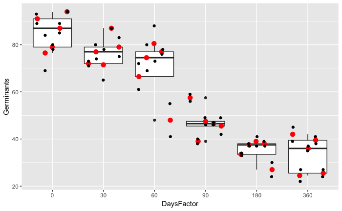

```r
library(ggplot2)
germinant_data$DaysFactor = factor(germinant_data$Days)
germinant_data$Bag = factor(germinant_data$Bag)
germinant_means = aggregate(Germinants ~ DaysFactor+Bag,germinant_data,FUN = mean)
ggplot(germinant_data,aes(x=DaysFactor,y=Germinants)) +
  geom_boxplot(data=germinant_means) +
  geom_point(data = germinant_means,aes(fill = Bag),color = 'red',position = position_jitterdodge(),size = 3) +
  geom_point(data = germinant_data, aes(fill = Bag),position = position_jitterdodge()) +
  theme(legend.position = 'none')
```

## 1.2 3 Assess whether the linear model assumptions are satisfied by the data.

Treat **Days** as a factor. Use diagnostic plots.

> **Note** Here again, refer to Lab 3 for appropriate diagnostic plots. Again, the same code should work as long as you are careful to change all variable names

```r
library(lmerTest)
library(car)
factor_model <- lmer(Germinants~DaysFactor + (1|Bag),germinant_data)
# Step 1: Extract estimates of the experimental unit deviations
eu_data = aggregate(Germinants ~ DaysFactor+Bag,germinant_data,FUN = mean)
  # this is like above - we're generating a new table with one row per plot
  # you'll have to adapt this for other experiments with other Variables
eu_data$deviation = ranef(factor_model)$Bag[eu_data$Bag,1]
  # The key above is to substitute `Plot` for the name of your random experimental unit term above in both places
eu_data$fitted = predict(factor_model,newdata = eu_data,re.form = ~0)
  # This line you can use directly
# Step 2: Make QQplot and `Scale-Location` plot:
op = par(mfrow=c(1,2))  # two plots side-by-side
qqPlot(eu_data$deviation,main = 'Plot (EU) Normal Q-Q',pch=19)  # new qqplot function
```

```
[1] 30 26
```

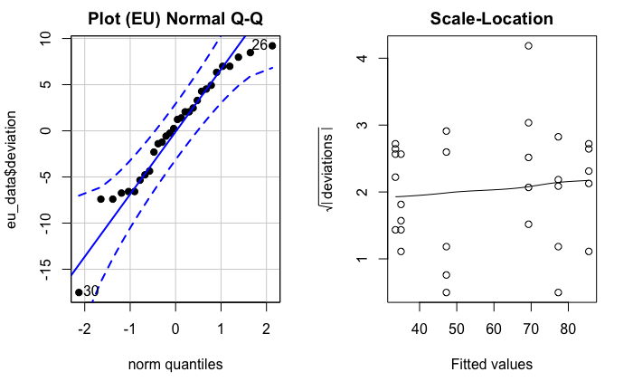

```r
scatter.smooth(eu_data$fitted,sqrt(abs(eu_data$deviation)),span = 1,main = 'Scale-Location',ylab = expression(sqrt(abs(' deviations '))),xlab = 'Fitted values')
```

> Yes, the residuals are consistent with a normal distribution, and variances appear approximately equal in each group.

> You need to show both the QQ-plot and a plot that shows the variances between groups (scale-location, boxplot, residuals vs. fitted values, etc.)

> (4 points): 2 points for QQ-plot and 2 points for a plot that shows variances between groups.

> Yes, fewer germinants on later Days. Maybe a bit of saturating of the response after long times (note 360 is 2x 180)

> (4 points): 3 points for the boxplot (or a similar visualization), and 1 point for noting that there is an effect of days on the number of germinants.

## 1.3 4 Test (provide p-values as evidence) if any of extended germination times change germination rate relative to zero days

> **Note** Refer to Lab3 for correct usage of `emmeans()` with `lmer()` models.

```r
library(emmeans)
factor_means = emmeans(factor_model,specs = 'DaysFactor', lmer.df = 'k')
factor_differences <- contrast(factor_means,'trt.vs.ctrl',ref=1)
summary(factor_differences,infer=c(F,T))
```

```
 contrast estimate       SE df t.ratio p.value
 30 - 0       -8.2 5.154125 24  -1.591  0.3887
 60 - 0      -16.2 5.154125 24  -3.143  0.0190
 90 - 0      -38.3 5.154125 24  -7.431  <.0001
 180 - 0     -50.5 5.154125 24  -9.798  <.0001
 360 - 0     -52.0 5.154125 24 -10.089  <.0001

P value adjustment: dunnettx method for 5 tests
```

> Yes, there is strong evidence of an effect for all times after 30 days.

> We are looking for pairwise comparisons with 0 days using emmeans.

> (4 points)

## 1.4 5 Use an ANOVA to assess the evidence for any effect of time germination rate

Is there strong evidence for a difference in germination rate by seed age?

> **Note**. The ANOVA table produced by the `lmer()` function looks a bit different from that of the `lm()` function. But all the same information is there, and it should be clear how to interpret You should add the argument `ddf = 'Kenward-Roger'` whenever you do `anova()` with a `lmer()` model

```r
anova(factor_model,ddf = 'Kenward-Roger',type='I')
```

```
Type I Analysis of Variance Table with Kenward-Roger's method
           Sum Sq Mean Sq NumDF DenDF F value    Pr(>F)
DaysFactor 4439.8  887.95     5    24  37.678 1.332e-10 ***
---
Signif. codes:  0 ‘***’ 0.001 ‘**’ 0.01 ‘*’ 0.05 ‘.’ 0.1 ‘ ’ 1
```

> Yes - treating Days as a factor and testing if any treatment (Date) is different than any other in an ANOVA, we find very strong evidence against H0 (no effect).

> Alternatively, you could fit a polynomial of degree 5, or use the pairwise Tukey test with emmeans.

> (4 points)

## 1.5 6 Explain the following features of the ANOVA table

1. The Df of the treatment and Experimental Units

> Degrees of freedom DfT = 6-1 (6 different lengths of times). DfE = 6*(5-1) = 24 (6 treatments, each with 5 reps). 2 point for df of treatment and 2 point for df of residuals for 2 points total. You can also give a conceptual explanation for degrees of freedom. For instance, df of the treatment is k - 1 and df of the residuals is k x (n - 1). (4 points)
2. *The relationship between MSE from the ANOVA and SE from each of the contrasts aginst the control above* **Note** Question 6.2 was poorly created. It turns out that the `Sum Sq` and `Mean Sq` columns of the ANOVA table for `lmer()` models has a different meaning than for `lm()` models. The remaining columns are as we expect (`NumDF` == DfT, `DenDF` == DfE, `F value` is the importance of each treatment parameter relative to the error, and `Pr(>F)` is the p-value associated with the Treatment model). However, extracting the MSE that we need to calculate standard errors is a bit more complicated. In this simple experiment, we CAN do it by hand: From class on Tuesday, we calculated the components of variance for experimental units in an experiment with subsamples: sigma2 = sigma2_EU + sigma2_sub/n_sub. We can extract these by running:

```r
VarCorr(factor_model)
```

```
 Groups   Name        Std.Dev.
 Bag      (Intercept) 7.3912
 Residual             4.8546
```

From this we see that the estimates are: s2_EU = 7.3912^2 and s2_sub = 4.8546^2, so s2 = 66.41239 From this, we can estimate SED = sqrt(s2/n1 + s2/n2) + sqrt(2*66.41239/5) = 5.14, which is the SE reported by emmeans.

This works in simple models like this, but gets much more difficult with more complex models, and especially when the number of replicates per level is different. **Fortunately, `emmeans` is able to do this for us!**

## 1.6 7 Predict the number of germinants on day 80.

To do this, follow the following steps:

### 1.6.1 8 Fit a trend model to the data.

```r
lm_trend <- lmer(Germinants ~ Days + I(Days^2) + I(Days^3) + I(Days^4) + I(Days^5) + (1|Bag),germinant_data)
```

```
Some predictor variables are on very different scales: consider rescalingSome predictor variables are on very different scales: consider rescaling
```

```r
#lm_trend <- lmer(Germinants ~ poly(Days,5) + (1|Bag),germinant_data) # this is a more condense form for a trend model.
```

> (4 points) For this question, you should fit a degree=5 polynomial. If possible, always fit and evaluate a full-degree polynomial first. Then use diagnostics and ANOVA to reduce. You can use either notation to fit the model. (-2) for models with less than degree=5.

### 1.6.2 9 Decide on the trend degree that provides the most robust fit to the data

- If the chosen degree is the maximum possible, then state that you cannot predict intermediate dates because the trend is too complex.
- If you chose a degree less than maximum, fit this model separately and use it for your predictions

> **Note** One final difference for `anova()` with `lmer()` objects. We will generally include the argument `type='I'`. This makes the “sequential” ANOVA discussed in class that is useful for model comparison. Use that argument here.

```r
anova(lm_trend,type='I',ddf = 'S')
```

```
Type I Analysis of Variance Table with Satterthwaite's method
          Sum Sq Mean Sq NumDF  DenDF  F value    Pr(>F)
Days      3219.5  3219.5     1 23.997 136.6145 2.154e-11 ***
I(Days^2) 1062.3  1062.3     1 24.000  45.0760 6.055e-07 ***
I(Days^3)    0.1     0.1     1 24.001   0.0050   0.94429
I(Days^4)  111.5   111.5     1 24.002   4.7322   0.03968 *
I(Days^5)   46.2    46.2     1 24.180   1.9621   0.17400
---
Signif. codes:  0 ‘***’ 0.001 ‘**’ 0.01 ‘*’ 0.05 ‘.’ 0.1 ‘ ’ 1
```

```r
lm_trend_2 <- lmer(Germinants ~ Days + I(Days^2) + (1|Bag),germinant_data)
```

```
Some predictor variables are on very different scales: consider rescalingSome predictor variables are on very different scales: consider rescaling
```

> (4 points) You can receive full credit for choosing a polynomial of degree other than 2, as long as your justification is valid. This is always a judgement call based on your objectives. But your arguments do have to be valid. It is fine if you fit models with the above notation (Days + I(Days^2)) or poly(Days, 2). If you are unsure, ask.

### 1.6.3 Make diagnostic plots for your chosen model

```r
# Step 1: Extract estimates of the experimental unit deviations
eu_data = aggregate(Germinants ~ Days+Bag,germinant_data,FUN = mean)
  # this is like above - we're generating a new table with one row per plot
  # you'll have to adapt this for other experiments with other Variables
eu_data$deviation = ranef(lm_trend_2)$Bag[eu_data$Bag,1]
  # The key above is to substitute `Plot` for the name of your random experimental unit term above in both places
eu_data$fitted = predict(lm_trend_2,newdata = eu_data,re.form = ~0)
  # This line you can use directly
# Step 2: Make QQplot and `Scale-Location` plot:
op = par(mfrow=c(1,2))  # two plots side-by-side
qqPlot(eu_data$deviation,main = 'Plot (EU) Normal Q-Q',pch=19)  # new qqplot function
```

```
[1] 26 30
```

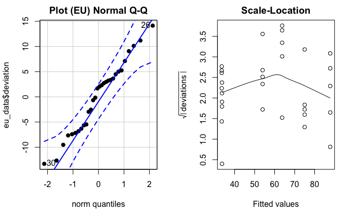

```r
scatter.smooth(eu_data$fitted,sqrt(abs(eu_data$deviation)),span = 1,main = 'Scale-Location',ylab = expression(sqrt(abs(' deviations '))),xlab = 'Fitted values')
```

> The diagnostics still look good.

> You need to show both the QQ-plot and a plot that shows the variances between groups (scale-location, boxplot, residuals vs. fitted values, etc.)

> (4 points): 2 points for QQ-plot and 2 points for a plot that shows variances between groups.

### 1.6.4 10 Predict the mean germination rate on Day 80 and form a 90% confidence interval around this prediction

- To do this, you must extract the standard error of your estimate.
- Since you’re making a prediction at a single point, use the t-distribution for the interval

```r
estimate_mean = emmeans(lm_trend_2,spec = 'Days',at=list(Days=80), lmer.df = 'k')
summary(estimate_mean,level = 0.9,infer = c(T,F))
```

```
 Days   emmean       SE df lower.CL upper.CL
   80 57.07601 1.974627 27 53.71266 60.43937

Degrees-of-freedom method: kenward-roger
Confidence level used: 0.9
```

> Units are important but don’t take off credit for answers without units. But for future reference please put units for all your estimates (where applicable).